# Ejemplo de modelos de abundancia N-mixtos en `unmarked`

SMandujanoR

2020-10-07

# Introducción

- Los modelos N-mixtos son modelos jerárquicos.
- En comparación con los modelos de ocupación, los N-mixtos son menos conocidos pero van teniendo más aceptación pues el tipo de datos que requiere se basa en el conteo (no en la presencia/ausencia) obtenidos con diferentes tipos de métodos como el foto-trampeo.
- Estos modelos combinan un submodelo del llamado estado o variable latente, en este caso , y otro submodelo de las observaciones el cual es condicional a .
- En la mayoría de los modelos N-mixtos, el submodelo observacional se basa en el modelo de la distribución binomial el cual es una pieza básica en los métodos de captura-recaptura; mientras que el submodelo de estado latente típicamente se modela empleando la distribución Poisson el cual es la pieza básica para estimar la abundancia (Royle y Dorazio 2008, Royle et al. 2014).

## Formalmente

Se pueden expresar como:

$$\begin{equation}
N_{i} \sim Poisson(\lambda)
\end{equation}$$
$$\begin{equation*}
C_{ij} \mid N_{i} \sim Binomial(N_{i}, p)
\end{equation*}$$

El primero es el submodelo del proceso de estado y el segundo el submodelo del proceso observacional.

$\textit{N}_{i}$ es la abundancia latente del sitio , y $\lambda$ (Lambda) es la abundancia esperada también conocida como el promedio de abundancia sobre todos los sitios (muestrados y no muestreados).

- Bajo diferentes formulaciones del modelo, Lambda también pude ser definida como la densidad promedio por sitio.
- Por otra parte, $\textit{C}_{ij}$ es el conteo de individuos en el -sitio durante el -muestreo (), y es la probabilidad de detección -individual.

## N-mixtos también conocidos como Binomial-Poisson

- Estos modelos pueden llamarse como binomial-Poisson N-mixto consiste de dos GLMs:
  - una regresión Poisson para la variación espacial de la abundancia, y
  - una regresión binomial (parecida al tipo logístico) para la variación de los conteos observados en los sitios muestreados.

# Objetivo de la presentación

Ejemplificar los modelos N-mixtos a partir de un conjunto de datos de esta información.

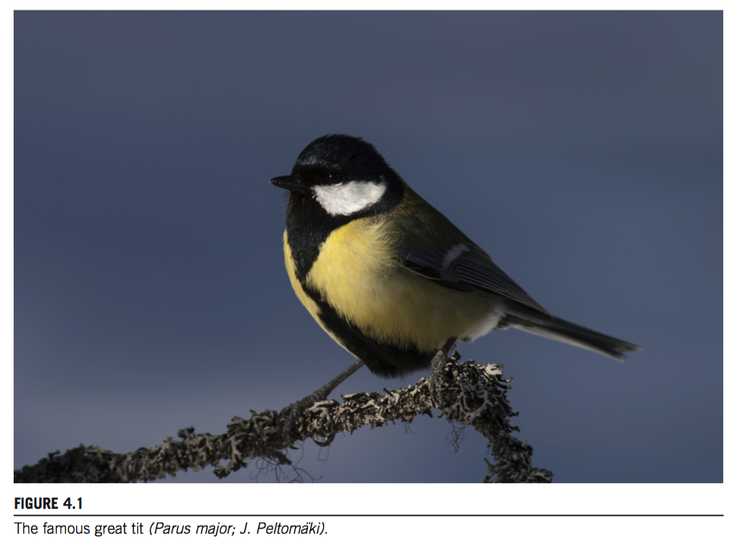

Basado en Capítulo 6.9 (pg.254-279) del libro de Kéry y Royle (2016): **Applied Hierarchical Modeling inEcology: Analysis od Distribution, Abundance and Species Richness in R and BUGS**.

# Datos del muestreo

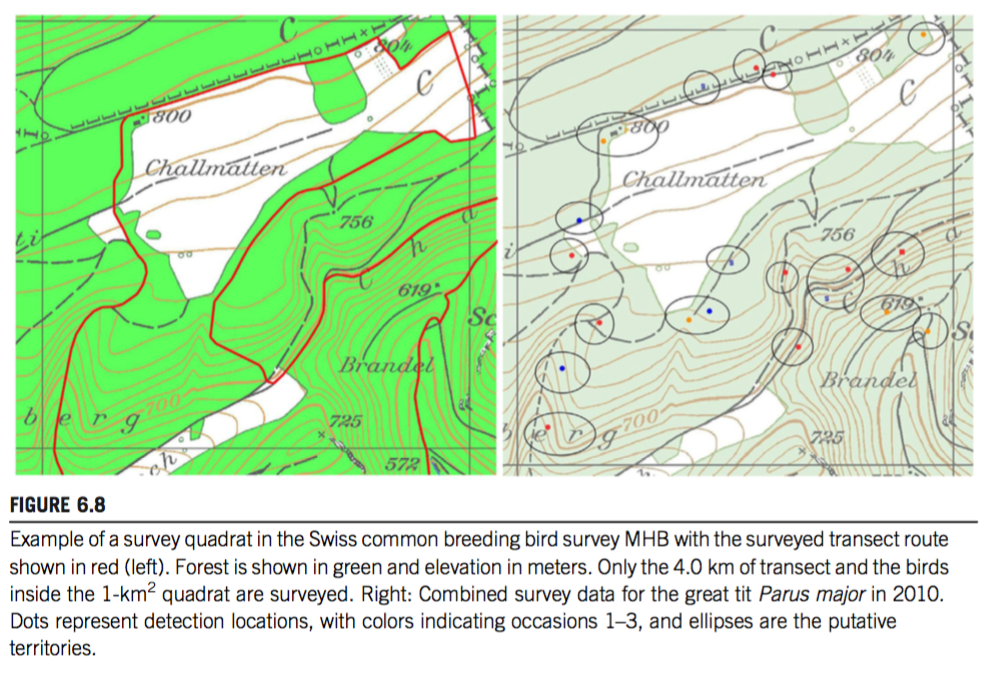

1. El monitoreo de la avifauna en Suiza se realiza anualmente en 267 cuadrantes de $1 km^2$ en una gradilla de 41,000 $km^2$.
2. Grupos de voluntarios experimentados muestrean cuadrantes a lo largo de rutas que abarcan transectos de 1 a 9 km de longitud, con una media de 5.1 km.
3. Cada transecto es muestreado 3 veces durante la época de crianza (Abril a Julio) empleando el método de mapeo de territorios.
4. Los muestreos inicial al amancer y duran en promedio 4 h.
5. Los observadores registran en un mapa la ubicación de cada individuo observado e identifican las especies.
6. Además, son determinados los posibles territorios basado en el conocimiento de cada especie.

# Preparación de datos

- Los autores consideran para el análisis solo los *i*-cuadrantes que contienen datos sobre el número de territorios ($y_ij$) durante los *j*-muestreos en 2013.
- La base de datos contiene los conteos de las 6 especies de titis en Suiza durante 2004–2013.
- En principio, todos los 267 cuadrantes son muestreados anualmente, pero hay escepciones.
- Las covariables incluyen:
  - elevación o altitud (m)
  - porcentaje de bosque (%)
  - largo de la ruta de muestreo (km)
  - día del muestreo (día 1 = abril 1)
  - duración de cada muestreo (min).

# Modelos empleados

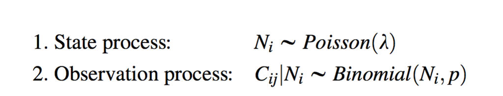

- Este es el modelo general principal donde además se asume que tanto Lambda ($\lambda$) como la probabilidad de detección (*p*) son afectados o están relacionados con covariables específicas.
- Sin embargo, dado que el largo de la ruta (o transecto) varió para cada cuadrante lo cual implicaría que rutas más largas incluyeron más área de muestre dentro del mismo cuadrante de $1 km^2$, se requiere corregir esta situación.
- En este ejemplo los autores usan el inverso del largo de la ruta como una covariable que afecta la abundancia. La idea es que dependiendo el largo del transecto la “población expuesta o disponible” al muestreo (*Ni*) es menor que la población local en todo el cuadrante (*Mi**). Pero a medida que el largo tiende a ser mayor, $N_i = M_i$.

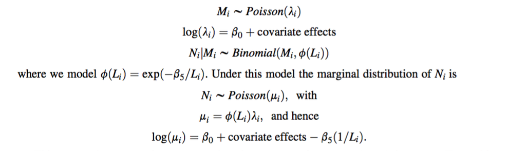

- Adicionalmente al empleo del modelo Poisson, los autores exploran dos modelos más: el binomial negativo (NB) y el cero-inflado Poisson (ZIP).
- Se sugiere analizar con detalle estos modelos en las páginas 256-257 del libro citado de Kéry y Royle (2016).

# Paso 1: preparación de los datos

## Leer datos:

```r
tits <- read.table("SwissTits_mhb_2004_2013.csv", header = T, sep = ";")
head(tits)
```

```
##   case specid latname      name coordx coordy AQ AQ.coordx AQ.coordy elev
## 1    1   3790  PARMAJ Great tit 922942  63276  1    920442    170224  450
## 2    2   3790  PARMAJ Great tit 928942  79276  2    930942    190724  450
## 3    3   3790  PARMAJ Great tit 928942 103276  3    930942    210724 1050
## 4    4   3790  PARMAJ Great tit 934942  95276  3    930942    210724  950
## 5    5   3790  PARMAJ Great tit 934942 111276  4    930942    220724 1150
## 6    6   3790  PARMAJ Great tit 946942  95276  5    950942    210724  550
##   rlength nsurvey forest count041 count042 count043 count051 count052 count053
## 1     6.4       3      3       NA       NA       NA       NA       NA       NA
## 2     5.5       3     21       21       14       13       16       18        8
## 3     4.3       3     32        2        6        3        4        3        3
## 4     4.5       3      9       NA       NA       NA       NA       NA       NA
## 5     5.4       3     35        4        0        2        4        6        2
## 6     3.6       3      2       NA       NA       NA       NA       NA       NA
##   count061 count062 count063 count071 count072 count073 count081 count082
```

[output cut: 76 more lines]

```r
names(tits)
```

```
##   [1] "case"      "specid"    "latname"   "name"      "coordx"    "coordy"
##   [7] "AQ"        "AQ.coordx" "AQ.coordy" "elev"      "rlength"   "nsurvey"
##  [13] "forest"    "count041"  "count042"  "count043"  "count051"  "count052"
##  [19] "count053"  "count061"  "count062"  "count063"  "count071"  "count072"
##  [25] "count073"  "count081"  "count082"  "count083"  "count091"  "count092"
##  [31] "count093"  "count101"  "count102"  "count103"  "count111"  "count112"
##  [37] "count113"  "count121"  "count122"  "count123"  "count131"  "count132"
##  [43] "count133"  "date041"   "date042"   "date043"   "date051"   "date052"
##  [49] "date053"   "date061"   "date062"   "date063"   "date071"   "date072"
##  [55] "date073"   "date081"   "date082"   "date083"   "date091"   "date092"
##  [61] "date093"   "date101"   "date102"   "date103"   "date111"   "date112"
##  [67] "date113"   "date121"   "date122"   "date123"   "date131"   "date132"
##  [73] "date133"   "dur041"    "dur042"    "dur043"    "dur051"    "dur052"
##  [79] "dur053"    "dur061"    "dur062"    "dur063"    "dur071"    "dur072"
##  [85] "dur073"    "dur081"    "dur082"    "dur083"    "dur091"    "dur092"
##  [91] "dur093"    "dur101"    "dur102"    "dur103"    "dur111"    "dur112"
##  [97] "dur113"    "dur121"    "dur122"    "dur123"    "dur131"    "dur132"
## [103] "dur133"    "obs2004"   "obs2005"   "obs2006"   "obs2007"   "obs2008"
## [109] "obs2009"   "obs2010"   "obs2011"   "obs2012"   "obs2013"
```

## Para ver las especies:

```r
table(tits$latname) # nombre latino
```

```
##
## PARATE PARCAE PARCRI PARMAJ PARMON PARPAL
##    267    267    267    267    267    267
```

```r
table(tits$name) # nombre en inglés
```

```
##
##    Blue tit    Coal tit Crested tit   Great tit   Marsh tit  Willow tit
##         267         267         267         267         267         267
```

## Selección de los datos del “Great tit” y las covariables del año 2013.

```r
tits <- tits[tits$latname == "PARMAJ",] # datos del ´great tit´
head(tits)
```

```
##   case specid latname      name coordx coordy AQ AQ.coordx AQ.coordy elev
## 1    1   3790  PARMAJ Great tit 922942  63276  1    920442    170224  450
## 2    2   3790  PARMAJ Great tit 928942  79276  2    930942    190724  450
## 3    3   3790  PARMAJ Great tit 928942 103276  3    930942    210724 1050
## 4    4   3790  PARMAJ Great tit 934942  95276  3    930942    210724  950
## 5    5   3790  PARMAJ Great tit 934942 111276  4    930942    220724 1150
## 6    6   3790  PARMAJ Great tit 946942  95276  5    950942    210724  550
##   rlength nsurvey forest count041 count042 count043 count051 count052 count053
## 1     6.4       3      3       NA       NA       NA       NA       NA       NA
## 2     5.5       3     21       21       14       13       16       18        8
## 3     4.3       3     32        2        6        3        4        3        3
## 4     4.5       3      9       NA       NA       NA       NA       NA       NA
## 5     5.4       3     35        4        0        2        4        6        2
## 6     3.6       3      2       NA       NA       NA       NA       NA       NA
##   count061 count062 count063 count071 count072 count073 count081 count082
```

[output cut: 76 more lines]

```r
NA.sites <- which(apply(is.na(tits[,41:43]), 1, sum) == 3) # sitios no muestreados
tits <- tits[-NA.sites,] # eliminación de esos sitios

y <- cbind(tits$count131,tits$count132, tits$count133) # conteos
date <- cbind(tits$date131,tits$date132, tits$date133) # día del muestreo
dur <- cbind(tits$dur131,tits$dur132, tits$dur133) # duración del muestreo
```

## Gráficamente el muestreo es:

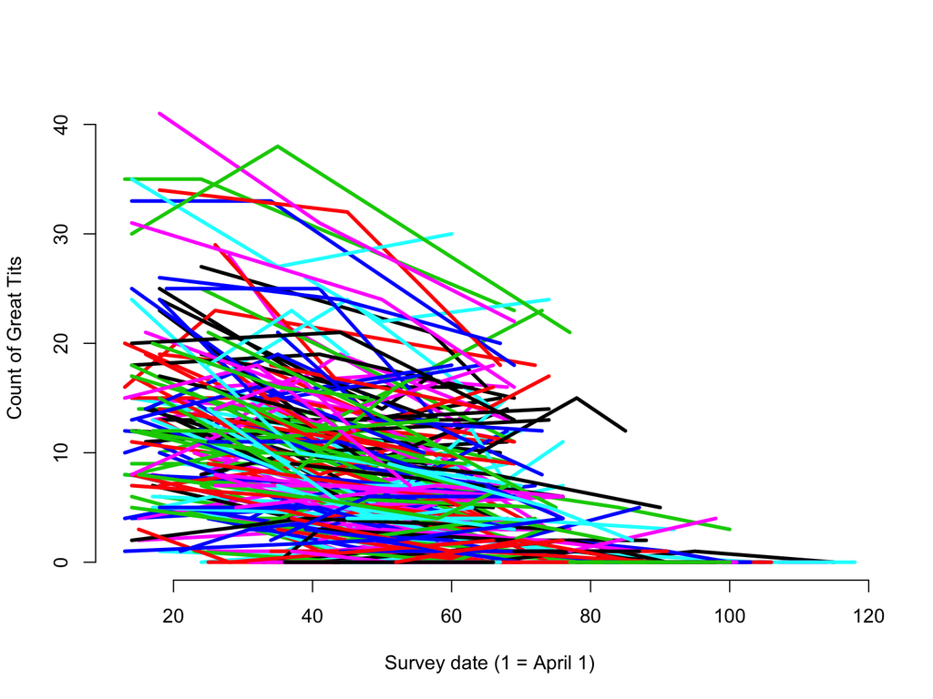

# Paso 2: Ajuste de modelos

## Cargar:

```r
library(unmarked)
```

## Modelo:

```r
time <- matrix(rep(as.character(1:3),
                   nrow(y)),
               ncol = 3,
               byrow = TRUE)

umf <- unmarkedFramePCount(y = y,
            siteCovs=data.frame(elev = scale(tits[,"elev"]),
            forest = scale(tits[,"forest"]),
            iLength = 1/tits[,"rlength"]),
            obsCovs = list(time = time,
            date = scale(date),
            dur = scale(dur)))

summary(umf)
summary(apply(y, 1, max, na.rm = TRUE))
```

- En este ejemplo se inicia con una modelo altamente parametrizado y se emplea la técnica de eliminación de covariables empleando los datos de los valores de P y de AIC.
- **Nota**: Para fines de esta presentación, nos saltaremos este proceso de selección y eliminación descrito en las páginas 259-260 del citado libro.
- Se considera el modelo final `fm5` y se compara contra los modelos `fm5NB`y `fm5ZIP`.

## Modelo Binomial-Poisson

```
> fm5 <- pcount(~(elev+I(elev^2)) * (date+I(date^2)) * (dur+I(dur^2)) + time-1 - elev:date:dur - elev:date:I(dur^2) - elev:I(date^2):dur - elev:I(date^2):I(dur^2) - I(elev^2):date:dur - I(elev^2):date:I(dur^2) - I(elev^2):I(date^2):dur - I(elev^2):I(date^2):I(dur^2) - I(elev^2):I(date^2) - I(elev^2)…

summary(fm5)

Abundance (log-scale):
                 Estimate     SE       z   P(>|z|)
(Intercept)        2.6713 0.1128  23.677 6.26e-124
elev              -1.2103 0.1012 -11.963  5.58e-33
I(elev^2)         -0.2741 0.0985  -2.783  5.38e-03
forest             0.0818 0.0627   1.305  1.92e-01
I(forest^2)       -0.1711 0.0464  -3.683  2.30e-04
iLength           -1.5902 0.4666  -3.408  6.54e-04
elev:forest       -0.0345 0.0620  -0.556  5.78e-01
elev:I(forest^2)  -0.0833 0.0491  -1.696  8.98e-02

Detection (logit-scale):
               Estimate     SE      z  P(>|z|)
elev            -0.1389 0.1851 -0.750 4.53e-01
I(elev^2)       -0.3379 0.1794 -1.884 5.96e-02
date            -0.2858 0.0990 -2.887 3.90e-03
I(date^2)        0.1250 0.0569  2.198 2.79e-02
dur              0.0983 0.0703  1.399 1.62e-01
I(dur^2)         0.0279 0.0337  0.829 4.07e-01
time1            0.5265 0.1234  4.268 1.98e-05
time2            0.1217 0.1173  1.038 2.99e-01
time3           -0.1951 0.1139 -1.713 8.67e-02
elev:date       -0.5484 0.1473 -3.724 1.96e-04
I(elev^2):date  -0.3026 0.1123 -2.694 7.07e-03
elev:dur         0.0311 0.0959  0.325 7.46e-01
elev:I(dur^2)    0.1393 0.0429  3.243 1.18e-03
I(elev^2):dur    0.2777 0.0799  3.477 5.07e-04
date:dur        -0.0361 0.0573 -0.629 5.29e-01
date:I(dur^2)   -0.0868 0.0411 -2.114 3.45e-02
```

## Modelo Binomial Negativa (NB)

```
> fm5NB <- pcount(fm5@formula, starts = c(coef(fm5),0), umf, control=list(trace=TRUE, REPORT=5), mixture = "NB")

 summary(fm5NB)

Abundance (log-scale):
                 Estimate     SE      z  P(>|z|)
(Intercept)        3.4385 0.3337 10.303 6.83e-25
elev              -1.1324 0.2838 -3.990 6.61e-05
I(elev^2)         -0.2159 0.2433 -0.887 3.75e-01
forest             0.0959 0.1048  0.915 3.60e-01
I(forest^2)       -0.2231 0.0860 -2.595 9.45e-03
iLength           -1.7340 1.0814 -1.603 1.09e-01
elev:forest       -0.0379 0.1094 -0.346 7.29e-01
elev:I(forest^2)  -0.1481 0.0989 -1.498 1.34e-01

Detection (logit-scale):
               Estimate     SE      z  P(>|z|)
elev            -0.1092 0.4092 -0.267 7.90e-01
I(elev^2)       -0.2611 0.3375 -0.773 4.39e-01
date            -0.1246 0.0935 -1.333 1.83e-01
I(date^2)        0.0497 0.0520  0.956 3.39e-01
dur              0.0274 0.0859  0.319 7.50e-01
I(dur^2)         0.0339 0.0386  0.877 3.80e-01
time1           -0.8111 0.3074 -2.639 8.32e-03
time2           -1.0556 0.3016 -3.500 4.65e-04
time3           -1.2790 0.2967 -4.311 1.62e-05
elev:date       -0.4347 0.1689 -2.574 1.00e-02
I(elev^2):date  -0.3883 0.1269 -3.061 2.21e-03
elev:dur         0.0349 0.1021  0.342 7.33e-01
elev:I(dur^2)    0.1091 0.0463  2.358 1.84e-02
I(elev^2):dur    0.2967 0.0892  3.324 8.86e-04
date:dur         0.0345 0.0489  0.704 4.81e-01
date:I(dur^2)   -0.0428 0.0343 -1.250 2.11e-01

Dispersion (log-scale):
 Estimate    SE    z P(>|z|)
    0.682 0.136 5.01 5.4e-07
```

## Modelo Zero-inflated Poisson (ZIP)

```
> fm5ZIP <- pcount(fm5@formula, starts = c(coef(fm5),0), umf, control=list(trace=TRUE, REPORT=5), mixture = "ZIP")

summary(fm5ZIP)

Abundance (log-scale):
                 Estimate     SE      z   P(>|z|)
(Intercept)        2.7564 0.1150 23.973 5.36e-127
elev              -0.9724 0.1237 -7.860  3.85e-15
I(elev^2)         -0.1726 0.1140 -1.514  1.30e-01
forest             0.0955 0.0642  1.487  1.37e-01
I(forest^2)       -0.1539 0.0509 -3.026  2.48e-03
iLength           -1.3412 0.4692 -2.859  4.26e-03
elev:forest       -0.0188 0.0634 -0.296  7.67e-01
elev:I(forest^2)  -0.0647 0.0543 -1.191  2.34e-01

Detection (logit-scale):
               Estimate     SE      z  P(>|z|)
elev            -0.3484 0.2033 -1.713 0.086651
I(elev^2)       -0.4088 0.1938 -2.109 0.034917
date            -0.2683 0.0981 -2.733 0.006270
I(date^2)        0.1195 0.0562  2.126 0.033498
dur              0.1179 0.0701  1.682 0.092597
I(dur^2)         0.0349 0.0336  1.040 0.298481
time1            0.3784 0.1333  2.838 0.004541
time2           -0.0177 0.1267 -0.140 0.888754
time3           -0.3274 0.1226 -2.671 0.007564
elev:date       -0.5501 0.1468 -3.747 0.000179
I(elev^2):date  -0.3313 0.1125 -2.945 0.003229
elev:dur         0.0700 0.0942  0.743 0.457517
elev:I(dur^2)    0.1498 0.0429  3.492 0.000479
I(elev^2):dur    0.2960 0.0798  3.707 0.000210
date:dur        -0.0458 0.0574 -0.797 0.425474
date:I(dur^2)   -0.0925 0.0412 -2.244 0.024803

Zero-inflation (logit-scale):
 Estimate    SE     z  P(>|z|)
    -2.48 0.332 -7.45 9.23e-14

AIC: 3636.058
Number of sites: 263
optim convergence code: 0
optim iterations: 130
Bootstrap iterations: 0
```

## Resumen comparativo de los tres modelos:

```
> cbind(fm5@AIC, fm5NB@AIC, fm5ZIP@AIC)

         [,1]     [,2]     [,3]
[1,] 3686.094 3181.046 3636.058

        lam(Int) p(time1) p(time2) p(time3)
Poisson    14.46     0.63     0.53     0.45
NegBin     31.14     0.31     0.26     0.22
ZIP        15.74     0.59     0.50     0.42
```

- De acuerdo a este análisis, el modelo candidato es el `fm5NB`.

## Análisis GoF

- **Nota**: para rapidéz y fines del ejemplo, solo se simulan 10 iteraciones. De lo contario una simulación n = 100 puede durar 4-5 horas! Pero para fines de una análisis adecuado, es necesario aumentar el número de simulaciones.

```
library(AICcmodavg)

> system.time(gof.P <- Nmix.gof.test(fm5, nsim=100))
> gof.P
```

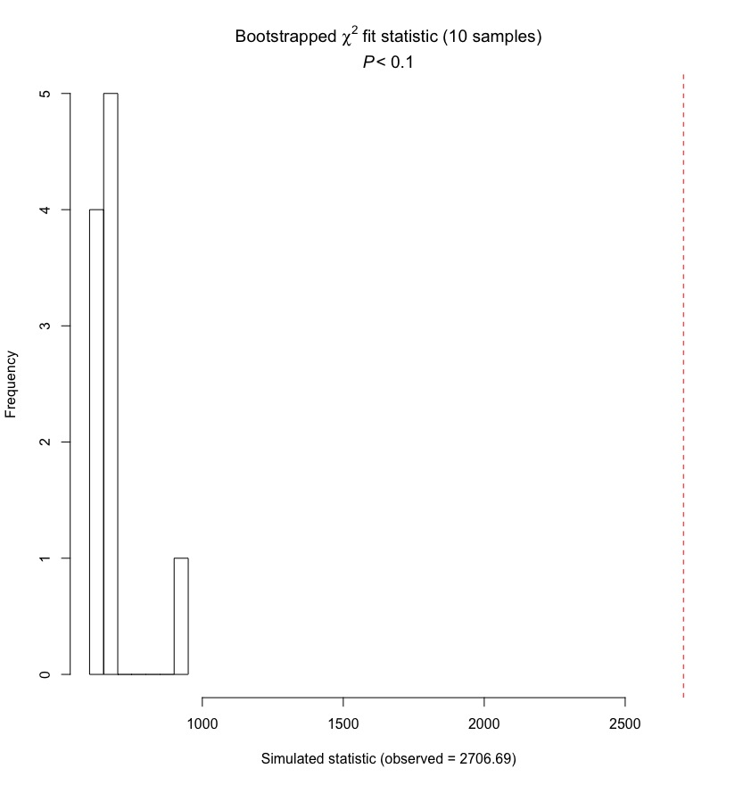

```
> system.time(gof.NB <- Nmix.gof.test(fm5NB, nsim=100))
> gof.NB
```

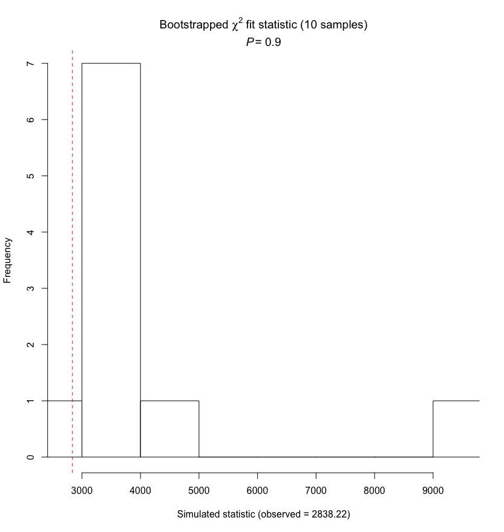

```
> system.time(gof.ZIP <- Nmix.gof.test(fm5ZIP, nsim=100))
> gof.ZIP
```

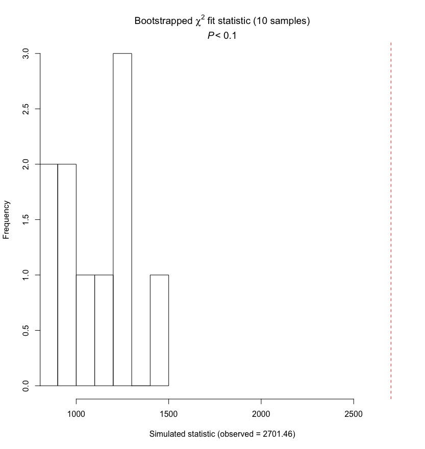

## Los resultados del ajuste se pueden visualizar y analizar gráficamente:

```
> library(AHMbook)

> plot.Nmix.resi(fm5, fm5NB, fm5ZIP)
```

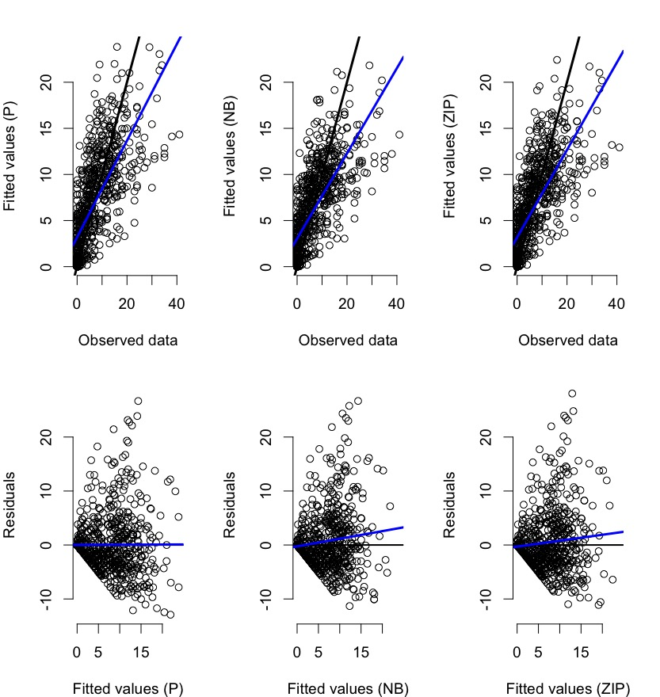